# Wavelet Components

Jeffrey D Walker, PhD

August 18, 2014

## Load Data

First, load some libraries and the climate data.

```r
library(dplyr)
library(tidyr)
library(stringr)
library(lubridate)
library(ggplot2)
theme_set(theme_bw())
library(weatherGen)
library(forecast)
```

```r
data(climate)

# compute daily averages across sites
clim.da <- group_by(climate, DATE) %>%
  summarise(N=n(),
            PRCP=mean(PRCP),
            TMIN=mean(TMIN),
            TMAX=mean(TMAX))

# aggregate by water year
clim.wyr <- clim.da %>%
  mutate(WYEAR=wyear(DATE)) %>%
  group_by(WYEAR) %>%
  summarise(N=n(),
            PRCP=sum(PRCP),
            TMIN=mean(TMIN),
            TMAX=mean(TMAX))
```

This figure shows the annual precipitation timeseries (by water year).

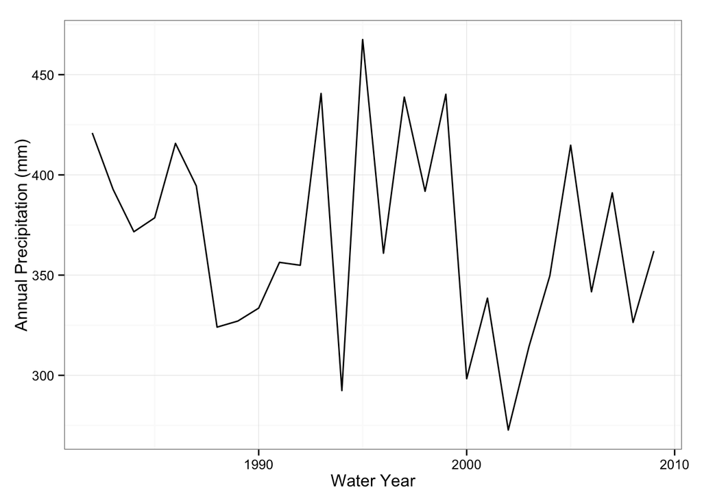

```r
ggplot(clim.wyr, aes(WYEAR, PRCP)) +
  geom_line() +
  labs(x="Water Year", y="Annual Precipitation (mm)")
```

## Wavelet Analysis

The timeseries is first analyzed using the `wavelet_analysis()` function, which returns the wavelet transform and associated information.

```r
wt.wgen <- wavelet_analysis(x=clim.wyr$PRCP, sig.level=0.90, noise.type="white")
```

The following figure shows the power of the time-averaged global wave spectrum and the significance level for each period using a white background noise and a threshold of 0.90.

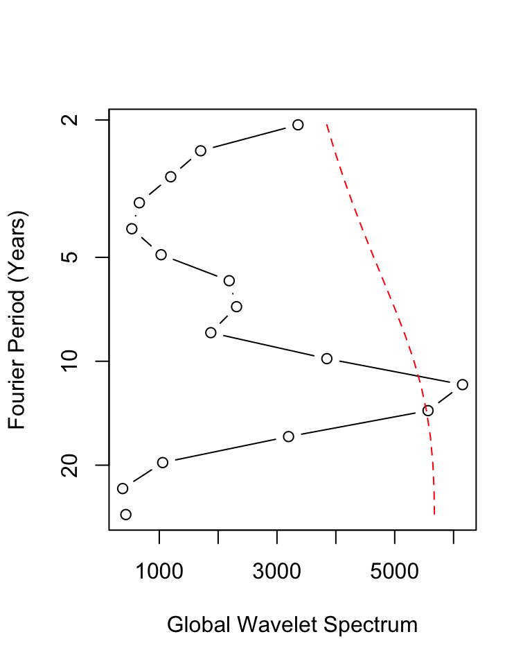

```r
plot(wt.wgen$gws, wt.wgen$period, type="b",
     xlab="Global Wavelet Spectrum", ylab="Fourier Period (Years)",
     log="y", ylim=rev(range(wt.wgen$period)),
     xlim=range(c(wt.wgen$gws, wt.wgen$gws.sig$signif)))
lines(wt.wgen$gws.sig$signif, wt.wgen$period, lty=2, col='red')
```

Using the result of the `wavelet_analysis()` function, the significant periods are identified.

```r
signif.periods.idx <- which(wt.wgen$gws > wt.wgen$gws.sig$signif)
signif.periods <- wt.wgen$period[signif.periods.idx]
print(signif.periods)
```

```
## [1] 11.69 13.90
```

## Wavelet Reconstruction

### weatherGen Package

Using the wavelet transform information, we can reconstruct each frequency component using the `wavelet_components()` function. The arguments to this function specify which components of the wavelet transform should be combined. For example, if periods 11 and 12 are both significant, they can be combined into a single component as a sum. The arguments are:

- `n.periods`: the number of final (or ‘combined’) components to generate
- `sig.periods`: a numeric vector listing the individual components to combine (note if there are multiple combined components and `n.periods > 1`, then the groups are simply listed one after another in a single vector)
- `n.comp.periods`: the number of individual components in each of the `n.periods` combined components.

For example, if one wanted two final components with the first component being the sum of periods 2 and 3, and the second component being the sum of periods 10, 11, and 12 then `n.periods=2`, `sig.periods=c(2,3,10,11,12)`, and `n.comp.periods=c(2,3)`.

We can use this function to recreate each individual components by simply setting:

- `n.periods = length(periods)`
- `sig.periods = seq(1, max(period))`
- `n.comp.periods = rep(1, length(periods))`

The following code reconstructs each individual period.

```r
comps.wgen <- wavelet_components(x=clim.wyr$PRCP, wt=wt.wgen,
                                 n.periods=length(wt.wgen$period),
                                 sig.periods=seq(1,length(wt.wgen$period)),
                                 n.comp.periods=rep(1, length(wt.wgen$period)))
head(comps.wgen)
```

```
##      NOISE COMPONENT 1 COMPONENT 2 COMPONENT 3 COMPONENT 4 COMPONENT 5
## [1,] 381.3   -0.007591      3.2401       3.359       5.342       7.525
## [2,] 369.6    0.662588     -1.4298       1.701       4.275       2.675
## [3,] 380.9   -1.482958      0.4028      -2.731      -7.014      -8.352
## [4,] 371.3    2.198058     -0.8099      -2.035      -3.593      -4.385
## [5,] 378.9   -3.202434      0.2800       3.297       7.759       7.173
## [6,] 373.1    4.504458      1.6773       2.385       1.552       5.396
##      COMPONENT 6 COMPONENT 7 COMPONENT 8 COMPONENT 9 COMPONENT 10
## [1,]      6.0665     1.45077     -1.6113     -1.1124      -0.4622
## [2,]     -0.4854    -2.91859     -1.3930      0.6849       2.4526
## [3,]     -7.6690    -4.45452      0.5095      2.2769       4.9678
## [4,]     -3.7600    -0.09579      2.8519      2.8748       6.1832
## [5,]      6.3051     5.60406      3.2790      2.2474       5.5346
## [6,]      7.6861     5.35435      0.7123      0.8713       3.0108
##      COMPONENT 11 COMPONENT 12 COMPONENT 13 COMPONENT 14 COMPONENT 15
## [1,]       4.1663       7.0006       4.3515       0.4331      -0.5913
## [2,]       7.1098       7.2725       3.1046      -0.3721      -0.8398
## [3,]       8.4145       5.9547       1.2505      -1.2064      -1.0019
## [4,]       7.4835       3.2006      -0.9318      -1.9575      -1.0572
## [5,]       4.3267      -0.4833      -3.0877      -2.5165      -0.9950
## [6,]      -0.3724      -4.3315      -4.8473      -2.7933      -0.8159
##      COMPONENT 16
## [1,]       0.4510
## [2,]       0.6787
## [3,]       0.8921
## [4,]       1.0851
## [5,]       1.2513
## [6,]       1.3841
```

This figure shows each frequency component, and indicates which components are significant.

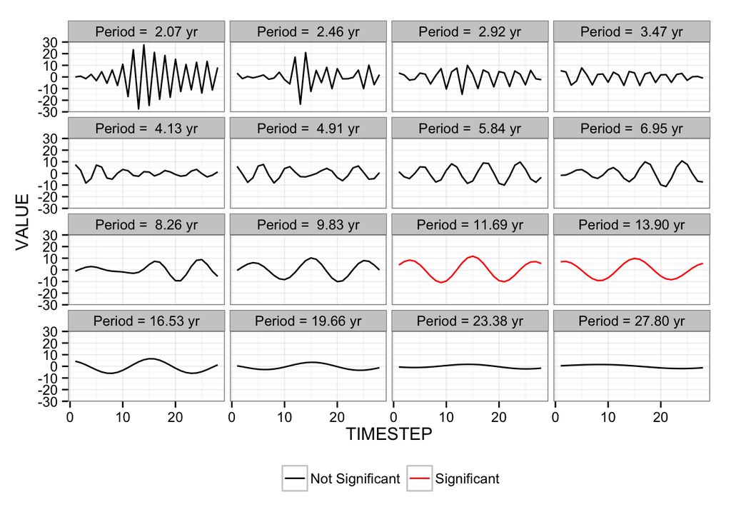

```r
df.comps.wgen <- as.data.frame(comps.wgen) %>%
  mutate(TIMESTEP=row_number()) %>%
  gather(COMPONENT, VALUE, -TIMESTEP) %>%
  filter(COMPONENT != "NOISE") %>%
  mutate(COMPONENT=str_replace_all(COMPONENT, 'COMPONENT ', ''),
         COMPONENT=as.numeric(as.character(COMPONENT)),
         IS.SIGNIF=COMPONENT %in% signif.periods.idx) %>%
  merge(data.frame(COMPONENT=seq(1, length(wt.wgen$period)), PERIOD=wt.wgen$period),
        by="COMPONENT", all.x=TRUE) %>%
  mutate(LABEL=paste0("Period = ", format(PERIOD, digits=3), ' yr'))

ggplot(df.comps.wgen, aes(TIMESTEP, VALUE, color=IS.SIGNIF)) +
  geom_line() +
  facet_wrap(~LABEL) +
  scale_color_manual('',
                     values=c('TRUE'='red', 'FALSE'='black'),
                     labels=c('TRUE'='Significant', 'FALSE'='Not Significant')) +
  theme(legend.position='bottom')
```

We can combine the significant periods into a single component.

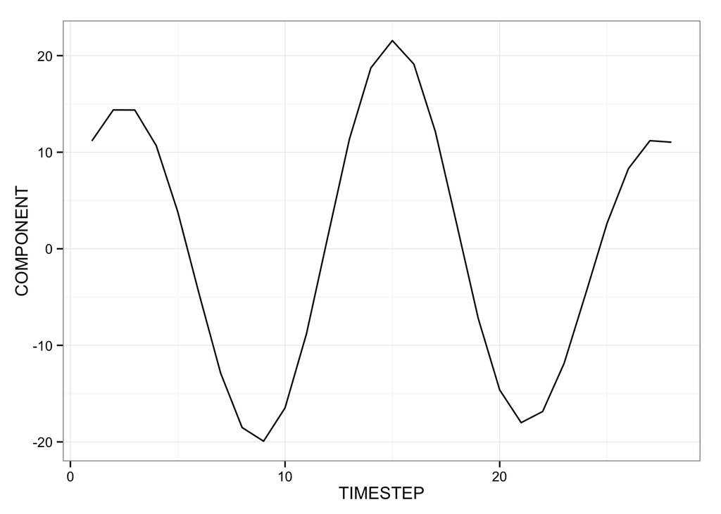

```r
comps.combine.wgen <- filter(df.comps.wgen, IS.SIGNIF) %>%
  group_by(TIMESTEP) %>%
  summarise(COMPONENT=sum(VALUE))
ggplot(comps.combine.wgen, aes(TIMESTEP, COMPONENT)) +
  geom_line()
```

We can then compute the noise component.

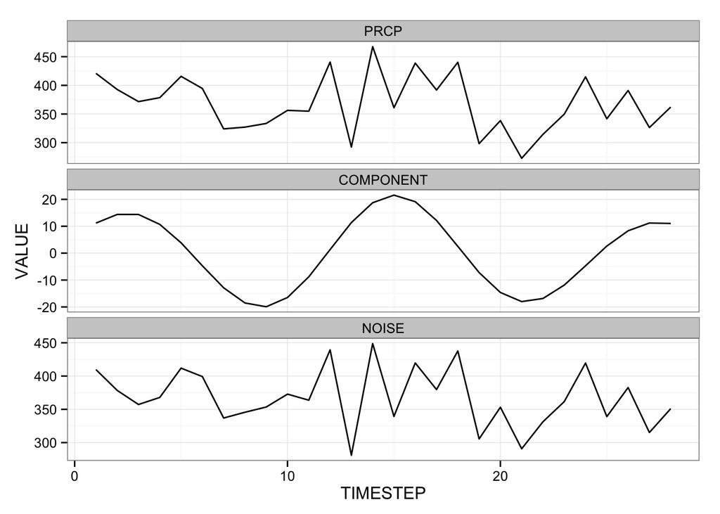

```r
comps.combine.wgen <- mutate(comps.combine.wgen,
                             PRCP=clim.wyr[['PRCP']],
                             NOISE=PRCP-COMPONENT)
comps.combine.wgen %>%
  gather(GROUP, VALUE, -TIMESTEP) %>%
  mutate(GROUP=ordered(as.character(GROUP), levels=c("PRCP", "COMPONENT", "NOISE"))) %>%
  ggplot(aes(TIMESTEP, VALUE)) +
  geom_line() +
  facet_wrap(~GROUP, ncol=1, scales='free_y')
```

Alternatively, the `wavelet_components()` function can combine the significant periods into a single component automatically. However, this only makes sense if the significant periods are contiguous (e.g. periods 11 and 12, but not 3 and 8).

```r
comps.wgen.sig <- wavelet_components(x=clim.wyr$PRCP, wt=wt.wgen,
                                     n.periods=1,
                                     sig.periods=signif.periods.idx,
                                     n.comp.periods=length(signif.periods.idx))
```

This figure shows the original data, combined component, and noise component.

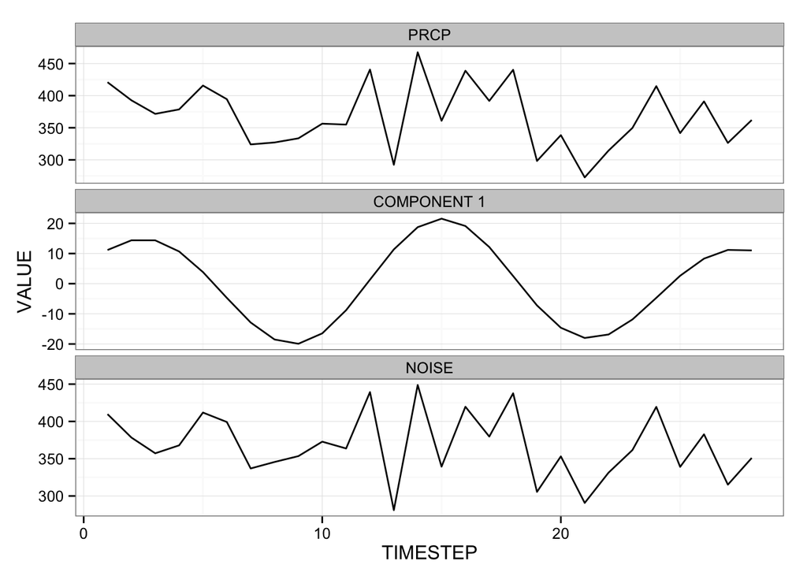

```r
as.data.frame(comps.wgen.sig) %>%
  mutate(PRCP=clim.wyr[['PRCP']],
         TIMESTEP=row_number()) %>%
  gather(GROUP, VALUE, -TIMESTEP) %>%
  mutate(GROUP=ordered(as.character(GROUP), levels=c("PRCP", "COMPONENT 1", "NOISE"))) %>%
  ggplot(aes(TIMESTEP, VALUE)) +
  geom_line() +
  facet_wrap(~GROUP, ncol=1, scales='free_y')
```

### Scott’s Scripts

The significant wavelet components can be reconstructed and combined using Scott’s `WAVELET_DECOMPOSITION()` function, which accepts the same arguments with the exception of the wavelet transform (which is computed within this function).

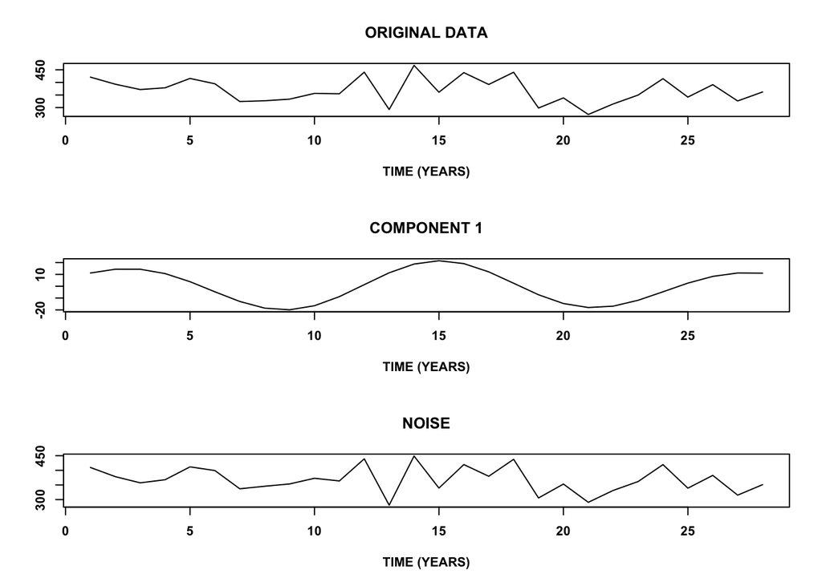

```r
comps.scott <- WAVELET_DECOMPOSITION(CLIMATE_VARIABLE=clim.wyr$PRCP,
                                     NUM_FINAL_PERIODS=1,
                                     ALL_SIG_PERIODS=c(signif.periods.idx),
                                     NUM_PERIODS_ALL_COMPS=length(signif.periods.idx),
                                     plot_flag=TRUE)
```

### Comparison

Comparing the result of `WAVELET_DECOMPOSITION()` and `wavelet_components()` for the significant components derived above yields identical values.

```r
cbind(scott=comps.scott[, 2], weatherGen=comps.combine.wgen$COMPONENT)
```

```
##         scott weatherGen
##  [1,]  11.167     11.167
##  [2,]  14.382     14.382
##  [3,]  14.369     14.369
##  [4,]  10.684     10.684
##  [5,]   3.843      3.843
##  [6,]  -4.704     -4.704
##  [7,] -12.882    -12.882
##  [8,] -18.513    -18.513
##  [9,] -19.930    -19.930
## [10,] -16.483    -16.483
## [11,]  -8.797     -8.797
## [12,]   1.327      1.327
## [13,]  11.363     11.363
## [14,]  18.741     18.741
## [15,]  21.560     21.560
## [16,]  19.128     19.128
## [17,]  12.152     12.152
## [18,]   2.527      2.527
## [19,]  -7.212     -7.212
## [20,] -14.621    -14.621
## [21,] -18.007    -18.007
## [22,] -16.854    -16.854
## [23,] -11.873    -11.873
## [24,]  -4.703     -4.703
## [25,]   2.630      2.630
## [26,]   8.309      8.309
## [27,]  11.195     11.195
## [28,]  11.036     11.036
```